# Paul Andrus MSDS - 660 Statistical Methods and Experimental Design

## Week 2 Lecture: Simple Linear Regression

16 May 2018

```r
rm(list = ls()) # Removes all objects to prevent results from previous runs being carried over into new runs.
graphics.off()  # Clears the graphic plots window
cat("\014")     # Clears the console
```

```r
getwd()
```

```
[1] "C:/Users/pandr/OneDrive/Regis/!MSDS660Stats/Wk2"
```

```r
# debug(utils:::unpackPkgZip) #Sometimes needed when "cannot move temporary installation" error. See https://stackoverflow.com/questions/34739681/unable-to-move-temporary-installation-when-installing-dependency-packages-in-r/44256437#44256437
# install.packages('MASS')
library(MASS)# https://cran.r-project.org/web/packages/MASS/MASS.pdf
```

### Investigate the relationship between two numerical variables graphically (e.g. scatter diagrams)

Let’s use MASS package Aids2 data set. “Data on patients diagnosed with AIDS in Australia before 1 July 1991.” Because you have had or will have MSDS-640 Ethics, Privacy, and Social Justice, “Note: This data set has been slightly jittered as a condition of its release, to ensure patient confidentiality.”

```r
head(Aids2)
```

|  | state | sex | diag | death | status | T.categ | age |
| --- | --- | --- | --- | --- | --- | --- | --- |
| 1 | NSW | M | 10905 | 11081 | D | hs | 35 |
| 2 | NSW | M | 11029 | 11096 | D | hs | 53 |
| 3 | NSW | M | 9551 | 9983 | D | hs | 42 |
| 4 | NSW | M | 9577 | 9654 | D | haem | 44 |
| 5 | NSW | M | 10015 | 10290 | D | hs | 39 |
| 6 | NSW | M | 9971 | 10344 | D | hs | 36 |

```r
str(Aids2)
```

```
'data.frame':   2843 obs. of  7 variables:
 $ state  : Factor w/ 4 levels "NSW","Other",..: 1 1 1 1 1 1 1 1 1 1 ...
 $ sex    : Factor w/ 2 levels "F","M": 2 2 2 2 2 2 2 2 2 2 ...
 $ diag   : int  10905 11029 9551 9577 10015 9971 10746 10042 10464 10439 ...
 $ death  : int  11081 11096 9983 9654 10290 10344 11135 11069 10956 10873 ...
 $ status : Factor w/ 2 levels "A","D": 2 2 2 2 2 2 2 2 2 2 ...
 $ T.categ: Factor w/ 8 levels "hs","hsid","id",..: 1 1 1 5 1 1 8 1 1 2 ...
 $ age    : int  35 53 42 44 39 36 36 31 26 27 ...
```

Aids2$diag and Aids2$death look like good candidates for the sake of illustration.

- diag = (Julian) date of diagnosis.
- death = (Julian) date of death or end of observation

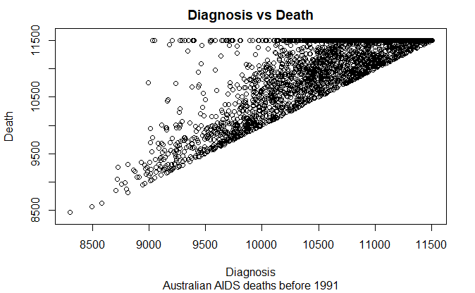

```r
plot(Aids2$diag,                                 # X coord
     Aids2$death,                                # Y coord
     main = "Diagnosis vs Death",                # Title
     sub = "Australian AIDS deaths before 1991", #Subtitle
     xlab = "Diagnosis",                              # X label
     ylab = "Death",                           #Y label
     asp = 0.5                                     # Y : X Aspect ratio
                                                   # < 1 stretches horizontally
     )
```

### Use linear regression to fit a line to the observations

#### Remove non-deaths

The horizontal line of data points represent patients who were still alive on the ending date. Patients alive at the end of the study represent open-ended or ambiguous data. Little conclusions could be drawn from these data points. First, determine the ending date of the study:

```r
summary(Aids2) # ID maxvalue = 11504
```

```
   state      sex           diag           death       status      T.categ
 NSW  :1780   F:  89   Min.   : 8302   Min.   : 8469   A:1082   hs     :2465
 Other: 249   M:2754   1st Qu.:10163   1st Qu.:10672   D:1761   blood  :  94
 QLD  : 226            Median :10665   Median :11235            hsid   :  72
 VIC  : 588            Mean   :10584   Mean   :10990            other  :  70
                       3rd Qu.:11103   3rd Qu.:11504            id     :  48
                       Max.   :11503   Max.   :11504            haem   :  46
                                                                (Other):  48
      age
 Min.   : 0.00
 1st Qu.:30.00
 Median :37.00
 Mean   :37.41
 3rd Qu.:43.00
 Max.   :82.00
```

#### Create working subset

Note that there is no point (11504, 11504). This eliminates a step; putting deaths back in that happened on the last study day.

```r
Aids3 <- subset(Aids2, select = c(diag, death)) # Many ways to do this
Aids3 <- Aids3[Aids3$death != 11504,]
summary(Aids3)
```

```
      diag           death
 Min.   : 8302   Min.   : 8469
 1st Qu.: 9934   1st Qu.:10267
 Median :10386   Median :10833
 Mean   :10321   Mean   :10683
 3rd Qu.:10759   3rd Qu.:11167
 Max.   :11478   Max.   :11503
```

#### Perform linear regression

```r
Aids3.lm <- lm(death ~ diag, Aids3) # save all outputs to an object
#The model formula is = intercept_coefficient + coefficient_var1*var1
```

### Calculate, and interpret parameters such as slope and coefficient of determination

```r
Aids3.lm
```

```
Call:
lm(formula = death ~ diag, data = Aids3)

Coefficients:
(Intercept)         diag
  1297.4191       0.9093
```

Why is the Y-intercept so low? Shouldn’t it be around 8500?

### Summarize the model fitting

#### Coefficient of determination

```r
summary(Aids3.lm)$r.squared # This is the coefficient of determination
```

```
[1] 0.7440357
```

#### Correlation coefficient

Correlation coefficient is a standard measurement of association or relationship between 2 variables. Typically, the symbol ρ (rho) denotes the population correlation (from the population data) and r is the sample correlation. Please keep in mind that correlation or association is not causation. As a reminder, regression is used to predict Y from X using a linear rule. Correlation describes how good the relationship is.

```r
cor(Aids3,
    use = "all.obs", # Specifies the handling of missing data. Options are all.obs (assumes no missing data - missing data will produce an error), complete.obs (listwise deletion), and pairwise.complete.obs (pairwise deletion)
    method = "pearson" # Specifies the type of correlation. Options are pearson, spearman or kendall.
      )
```

```
          diag    death
diag  1.000000 0.862575
death 0.862575 1.000000
```

p-value is the probability the correlation is because of random chance. Low p-value means reject the null hypothesis.

```r
summary(Aids3.lm)
```

```
Call:
lm(formula = death ~ diag, data = Aids3)

Residuals:
    Min      1Q  Median      3Q     Max
-498.17 -242.27  -62.15  186.99 1787.10

Coefficients:
             Estimate Std. Error t value Pr(>|t|)
(Intercept) 1.297e+03  1.308e+02   9.917   <2e-16 ***
diag        9.093e-01  1.266e-02  71.850   <2e-16 ***
---
Signif. codes:  0 *** 0.001 ** 0.01 * 0.05 . 0.1   1

Residual standard error: 308.9 on 1776 degrees of freedom
Multiple R-squared:  0.744, Adjusted R-squared:  0.7439
F-statistic:  5162 on 1 and 1776 DF,  p-value: < 2.2e-16
```

Let’s see what perfect correlation looks like:

```r
x <- c(1, 2, 3)
y <- c(1, 2, 3)
perfect <-cbind(x, y)
cor(perfect, method = "pearson")
```

```
  x y
x 1 1
y 1 1
```

```r
perfect.lm <- lm(x ~ y, data.frame(perfect)) # lm requires a data frame
summary(perfect.lm)
```

```
essentially perfect fit: summary may be unreliable
```

```
Call:
lm(formula = x ~ y, data = data.frame(perfect))

Residuals:
         1          2          3
 8.075e-18 -1.615e-17  8.075e-18

Coefficients:
             Estimate Std. Error   t value Pr(>|t|)
(Intercept) 0.000e+00  3.022e-17 0.000e+00        1
y           1.000e+00  1.399e-17 7.149e+16   <2e-16 ***
---
Signif. codes:  0 *** 0.001 ** 0.01 * 0.05 . 0.1   1

Residual standard error: 1.978e-17 on 1 degrees of freedom
Multiple R-squared:      1, Adjusted R-squared:      1
F-statistic: 5.111e+33 on 1 and 1 DF,  p-value: < 2.2e-16
```

## Now for the homework

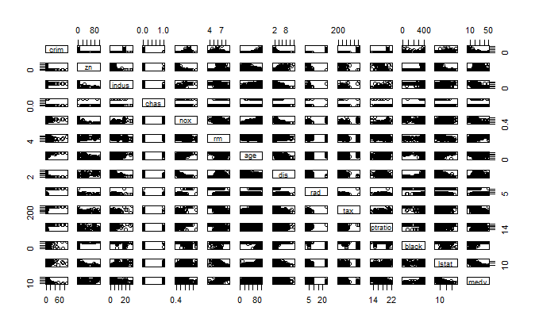

```r
plot(Boston)
```

That’s pretty messy. For this exercise, pick four variables.

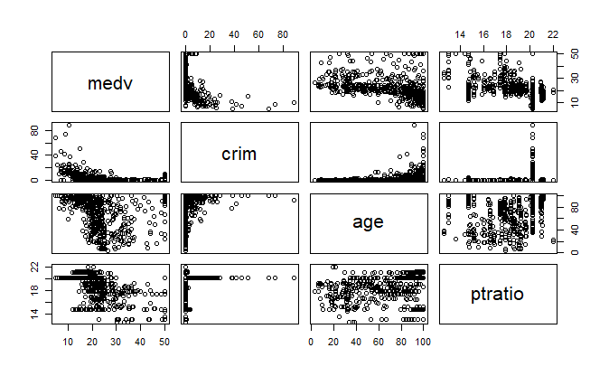

```r
Boston_4 <- subset(Boston, select = c("medv", "crim", "age", "ptratio"))
plot(Boston_4)
```

Maybe don’t pick those four.